# United States Incarceration Data Analysis

Scott Nguyen

2/25/2022

## Introduction

Within this project I’m looking to use the incarceration trends data set provided by Vera Institute of Justice in order to expose patterns of inequalities within our incarceration system. Due to the prevalence of the claim that their is an inequality between white and black incarceration, in this project I’m going to be mainly focusing on comparing the difference between white and black incarceration in order to come out with some data that may find inequalities between the two races within our criminal justice system. This data doesn’t provide enough information to make strong conclusions, but may provide information to help back up claims as data does not tell us the full story behind each case.

## Values of Interest

In my search for specific information I decided to focus on the year of **2018** and came out with the following conclusions:  
- **California** is the state with the **highest** amount of individuals in jail.  
- **Los Angeles** county was the county with the **highest** amount of individuals jailed.  
- There was a total of **247,546** black individuals, **346,061** white individuals, and a total of **737,126** individuals in jail in the year **2018**.  
- The proportion of black individuals in jail is **33.58%**, while the proportion of white individuals in jail is **46.95%**.  
- When taking the proportion of black and white individuals between the ages of 15-64 and comparing it to their respective races total jail population, **0.86%** of black individuals would be in jail while **0.27%** of white individuals would be in jail.

## Data Visualizations

The following chart displays the relation between the total individuals between the ages of 15-64 within each specific race compared to the total individuals that are in jail for that specific race. I chose this representation because I wanted to see a decently accurate per capita relation between races as I think this is one of the best ways to find inequalities between races. From this we find that the proportion of black individuals that are in jail is greatly higher when compared to other races ever since the start of the data.

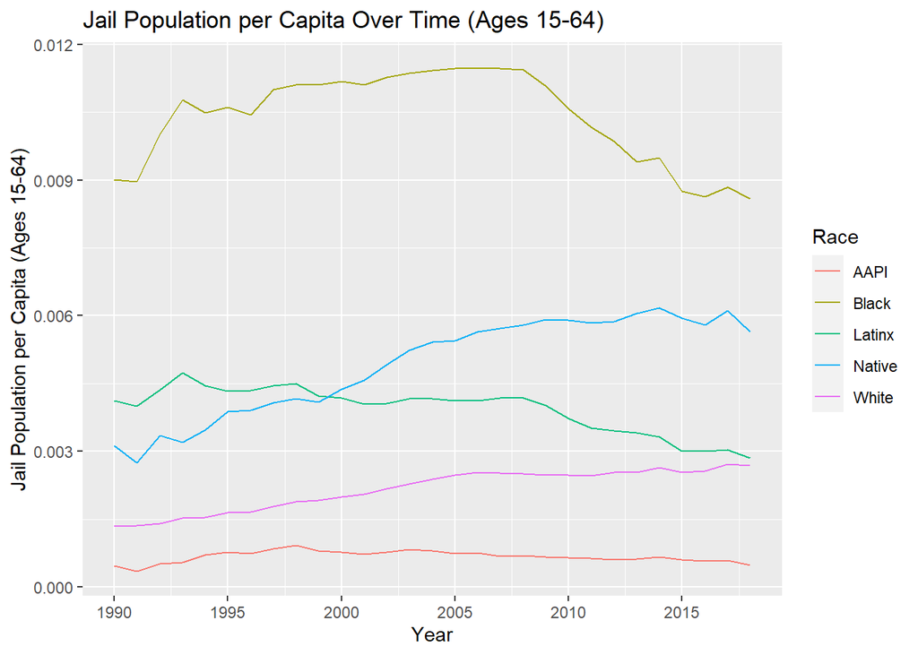

The following pie chart compares the total white individuals in jail to the total black individuals in jail. I chose to include this pie chart because it shows a possible visual representation that may cause confusion as the total white population of jailed individuals is greater than black individuals which could be used to come to claims that aren’t appropriate as the population of white individuals is greater than black individuals. This chart shows that if we purely look at the numbers without relating it to the population of that specific race we might come to a different conclusion as this shows a different story from the previous graph.

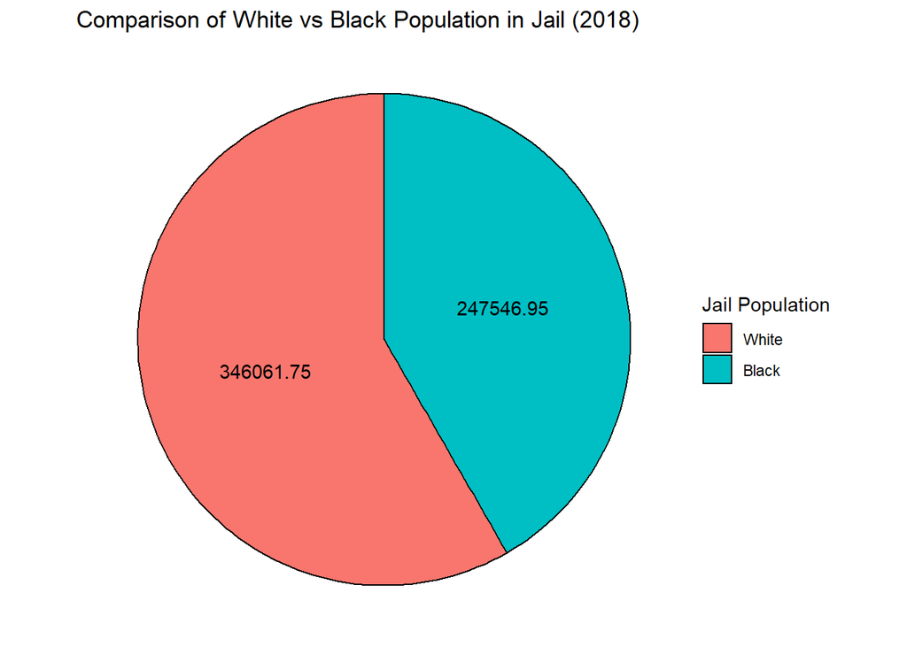

The following three maps show a map of black, white, and total jail incarcerations for specific counties throughout the United States for the year of 2018. I chose to do three maps because I think that choosing one doesn’t tell us a story that we can learn from, but looking at all three allows us to put into perspective what we are looking at. The following maps show that some locations have higher jail populations of other and shows within all maps.

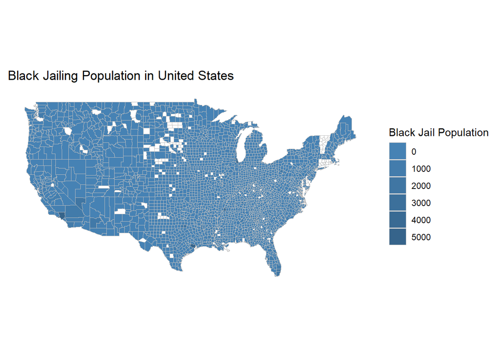

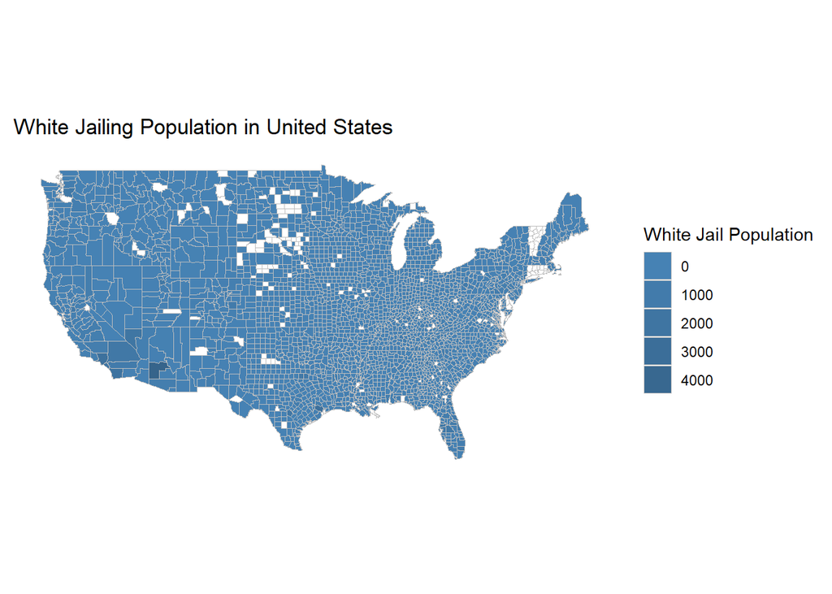

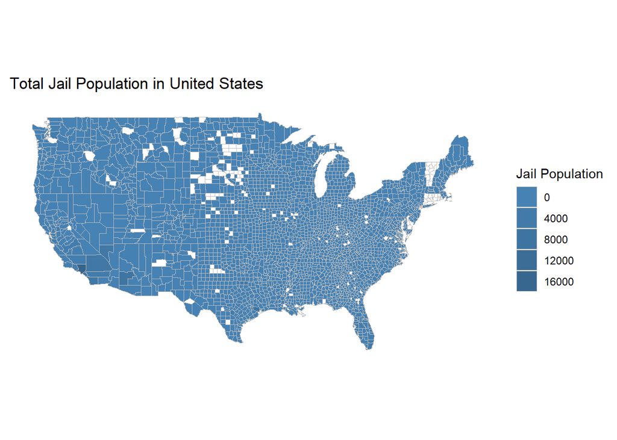